# Swisstransplant R cookbook

Reproducible, high-quality statistical reporting.

Author

Simon Schwab

Published

July 7, 2025

Abstract

The Swisstransplant R cookbook is a practical guide for generating reproducible, high-quality statistical reports using our custom R package `swt`.

## Introduction

This cookbook introduces the Swisstransplant R package `swt` to make high-quality reports and publication-ready graphics in our in-house style.

The source code for `swt` is maintained on GitHub and can be accessed [here](https://github.com/Swisstransplant/swt). Additionally, a [package manual](https://raw.githubusercontent.com/Swisstransplant/swt/main/manual/swt.pdf) is available for reference.

```r
library(ggplot2)
library(gridExtra)
library(reshape2)
library(swt)
library(readxl)
library(testit)
library(rms)
```

## Quarto document

The `swt` package includes the Swisstransplant template for creating Quarto documents. Quarto documents enable dynamic reporting and unite written text, statistical programming code, results, tables, and figures into a reproducible document.

To create a new Swisstransplant project in RStudio, click **New Project…**, select **New Directory**, and then choose **Swisstransplant Document** from the bottom of the list.

[figure not shown]

### Writing in Markdown

The Swisstransplant Quarto document is written in Markdown; an overview can be found in the [Markdown Basics](https://quarto.org/docs/authoring/markdown-basics.html). It is possible to add [Callout Blocks](https://quarto.org/docs/authoring/callouts.html) to highlight important information.

```r
::: {.callout-note appearance="simple"}
Note that there are five types of callouts, including:
`note`, `warning`, `important`, `tip`, and `caution`.
:::
```

Note that there are five types of callouts: `note`, `warning`, `important`, `tip`, and `caution`.

Something important.

## Data analysis workflow

The Quarto document introduces a simple data analysis workflow structured into eight chapters, each using second-level headings (##). The chapters are as follows:

- Objectives
- Data import
- Data processing
- Quality control
- Descriptive statistics
- Primary analysis
- Secondary analysis
- Computing information

Each chapter can be further expanded to support more complex analysis projects, as illustrated in the flowchart below.

Quarto documents that follow a structured analysis workflow enhance transparency, support reproducibility, and build trust in statistical analyses.

```
flowchart TB
O(Objectives) --> I(Data import)
I --> P(Data processing)
P --> Q(Quality control)
Q --> D(Descriptive statistics)
D --> A(Primary analysis)
A --> S(Secondary analyses)
S --> C(Computing information)
O --- OC[Study objectives<br>Primary outcome<br>Secondary outcomes<br>Methods]
I --- IC[Custom R functions<br>Load libraries<br>Two-pass reading when necessary<br>Data class conversion<br>Data cleaning<br>Reshape<br>Merge<br>Aggregate]
P --- PC[Data overview<br>Definition of outcomes<br>Consent status<br>Inclusion, exclusion and subsets<br>Missing data and imputations<br>Transform<br>Matching<br>Create analysis data set]
Q --- QC[Data checks<br>Assert logical expressions<br>Variable distributions]
D --- DC[Sample size<br>Table 1<br>Consort Diagram]
A --- AC[Results<br>Tables<br>Figures]
S --- SC[Results<br>Tables<br>Figures]
C --- CC[Runtime<br>Environment<br>Package names and versions]
```

## Corporate design

To support professional-looking output, the `swt` package provides a custom color palette and styling for creating `ggplot2` figures.

The color scheme and `ggplot2` styling are used in the official Swisstransplant national statistics to provide a professional and consistent visual presentation.

### Colors

The `swt_colors()` function creates an object for user-friendly access to the Swisstransplant color scheme:

```r
col = swt_colors()
col$blue.dark
```

The following colors are available:

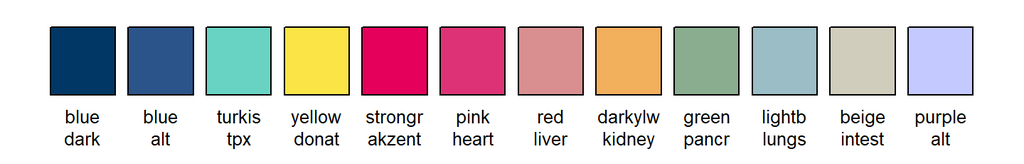

```r
col = swt_colors()
par(mfrow=c(1,1), mai=c(0.5,0.1,0.2,0.1))
barplot(rep(1,12), axes=FALSE, col=c(col$blue.dark,
                                     col$blue.alt,
                                     col$turkis.tpx,
                                     col$yellow.donation,
                                     col$strongred.akzent,
                                     col$pink.heart,
                                     col$red.liver,
                                     col$darkyellow.kidney,
                                     col$green.pancreas,
                                     col$lightblue.lungs,
                                     col$beige.intestine,
                                     col$purple.alt

),
names.arg = c("blue\ndark", "blue\nalt", "turkis\ntpx", "yellow\ndonat",
              "strongr\nakzent", "pink\nheart", "red\nliver", "darkylw\nkidney",
              "green\npancr", "lightb\nlungs", "beige\nintest", "purple\nalt"),
cex.names = 0.8

)
```

### Color palettes

The `swt_colors` object also includes single hue palettes with three additional color strengths: 75%, 50%, and 25%. Color palettes can be accessed as follows:

```r
col$pal.blue.dark[1] # 100%, same as col$blue.swt
col$pal.blue.dark[2] #  75%
col$pal.blue.dark[3] #  50%
col$pal.blue.dark[4] #  25%
```

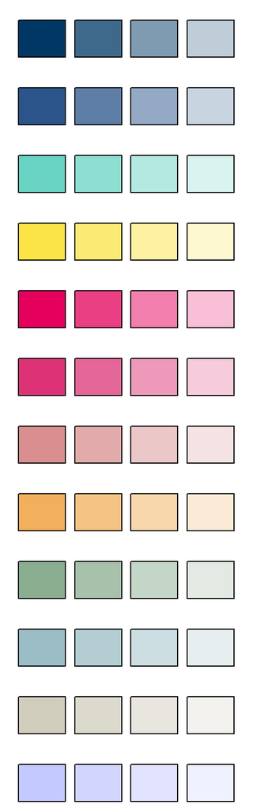

```r
par(mfrow=c(12,1), mai=c(0.1,0.1,0.2,0.1))

barplot(rep(1,4), axes=FALSE, col=c(col$pal.blue.swt[1],
                                    col$pal.blue.swt[2],
                                    col$pal.blue.swt[3],
                                    col$pal.blue.swt[4])
)

barplot(rep(1,4), axes=FALSE, col=c(col$pal.blue.alt[1],
                                    col$pal.blue.alt[2],
                                    col$pal.blue.alt[3],
                                    col$pal.blue.alt[4])
)

barplot(rep(1,4), axes=FALSE, col=c(col$pal.turkis.tpx[1],
                                    col$pal.turkis.tpx[2],
                                    col$pal.turkis.tpx[3],
                                    col$pal.turkis.tpx[4])
)

barplot(rep(1,4), axes=FALSE, col=c(col$pal.yellow.donation[1],
                                    col$pal.yellow.donation[2],
                                    col$pal.yellow.donation[3],
                                    col$pal.yellow.donation[4])
)

barplot(rep(1,4), axes=FALSE, col=c(col$pal.strongred.akzent[1],
                                    col$pal.strongred.akzent[2],
                                    col$pal.strongred.akzent[3],
                                    col$pal.strongred.akzent[4])
)

barplot(rep(1,4), axes=FALSE, col=c(col$pal.pink.heart[1],
                                    col$pal.pink.heart[2],
                                    col$pal.pink.heart[3],
                                    col$pal.pink.heart[4])
)

barplot(rep(1,4), axes=FALSE, col=c(col$pal.red.liver[1],
                                    col$pal.red.liver[2],
                                    col$pal.red.liver[3],
                                    col$pal.red.liver[4])
)

barplot(rep(1,4), axes=FALSE, col=c(col$pal.darkyellow.kidney[1],
                                    col$pal.darkyellow.kidney[2],
                                    col$pal.darkyellow.kidney[3],
                                    col$pal.darkyellow.kidney[4])
)

barplot(rep(1,4), axes=FALSE, col=c(col$pal.green.pancreas[1],
                                    col$pal.green.pancreas[2],
                                    col$pal.green.pancreas[3],
                                    col$pal.green.pancreas[4])
)

barplot(rep(1,4), axes=FALSE, col=c(col$pal.lightblue.lungs[1],
                                    col$pal.lightblue.lungs[2],
                                    col$pal.lightblue.lungs[3],
                                    col$pal.lightblue.lungs[4])
)

barplot(rep(1,4), axes=FALSE, col=c(col$pal.beige.intestine[1],
                                    col$pal.beige.intestine[2],
                                    col$pal.beige.intestine[3],
                                    col$pal.beige.intestine[4])
)

barplot(rep(1,4), axes=FALSE, col=c(col$pal.purple.alt[1],
                                    col$pal.purple.alt[2],
                                    col$pal.purple.alt[3],
                                    col$pal.purple.alt[4]),
        names.arg = c("100%", "75%", "50%", "25%"),
        cex.names = 0.8
)
```

## Plots with `ggplot2`

Below are a few examples of creating various types of data plots in the SWT color scheme. The function `swt_style()` adds the correct styling to the plot.

### Scientific plots

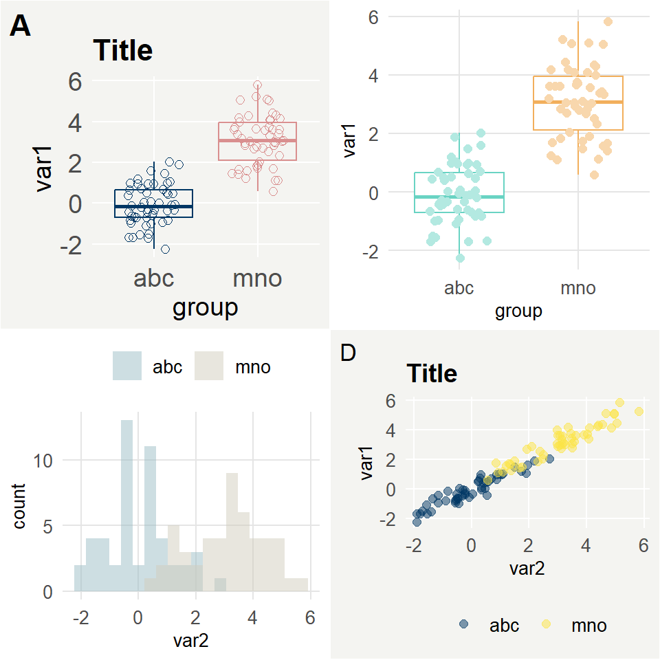

```r
set.seed(1980)
n = 100
var1 = c(rnorm(n/2, mean=0), rnorm(n/2, mean=3) )
d = data.frame(var1 = var1,
               var2 = var1 + rnorm(n, sd = 0.4),
               group = as.factor(rep(c("abc", "mno" ), each=n/2))
)

p1 = ggplot(d, aes(x=group, y=var1, group=group, col=group)) +
  geom_boxplot(fill=col$grey.bg) +
  geom_point(size=2, shape=1, position = position_jitter(height = 0, width = 0.25),
             col=c(rep(col$pal.blue.swt[1], n/2),
                   rep(col$pal.red.liver[1], n/2))) +
  labs(title = "Title", tag = "A") +
  scale_color_manual(values = c(col$blue.swt,
                                col$red.liver)) +
  swt_style(legend_position = "none", grey_theme = TRUE, font_size = 14, title_size = 16) +
  theme(plot.tag = element_text(size = 16, face = "bold"))

p2 = ggplot(d, aes(x=group, y=var1, group=group, col=group)) +
  geom_boxplot() +
  geom_point(size=2, position = position_jitter(height = 0, width = 0.25),
             col=c(rep(col$pal.turkis.tpx[3], n/2),
                   rep(col$pal.darkyellow.kidney[3], n/2))) +
  scale_color_manual(values = c(col$turkis.tpx,
                                col$darkyellow.kidney)) +
  swt_style(legend_position = "none")

p3 = ggplot(d, aes(x=var2, fill=group)) +
  geom_histogram(position = "identity", bins=20, alpha=0.5) +
  scale_fill_manual(values = c(col$lightblue.lungs,
                               col$beige.intestine)) +
  swt_style(grey_theme = FALSE)

p4 = ggplot(d, aes(x=var2, y=var1, group=group, col=group)) +
  geom_point(size=2, alpha=0.5) +
  scale_color_manual(values = c(col$blue.swt,
                                col$yellow.donation)) +
  labs(title = "Title", tag = "D") +
  swt_style(legend_position = "bottom", grey_theme = TRUE)

grid.arrange(p1, p2, p3, p4, nrow = 2, ncol = 2)
```

### Line plot

```r
# Data taken from Annual Report 2020 (p. 32)
table3.2 = t(array(c(
  13.3,17.2,18.6,18.4,17.0,
  11.5,12.6,14.9,11.7,11.2,
  1.8,4.6,3.8,6.7,5.8), dim = c(5,3)))

colnames(table3.2) = 2016:2020
rownames(table3.2) = c("Total", "DBD", "DCD")

data3.2 = melt(table3.2, varnames = c("Gruppe", "Jahr"), value.name = "Anzahl")
```

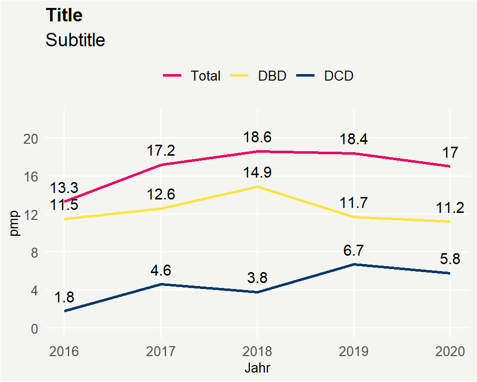

```r
number_height = -0.8

ggplot(data3.2, aes(x=Jahr, y=Anzahl, col=Gruppe, group=Gruppe)) +

  # plot line with numbers
  geom_line(data = data3.2, linewidth=1) +
  geom_text(data = data3.2, aes(label=Anzahl), vjust=number_height,
            col="black", size=4) +

  # some adjustments (colors, axes, etc)
  scale_color_manual(values=c(col$strongred.akzent,
                              col$yellow.donation,
                              col$blue.swt)) +
  scale_y_continuous(breaks = seq(0,22,4), limits = c(0,22)) +

  ylab("pmp") +
  labs(title="Title",
       subtitle = "Subtitle"
  ) +
  swt_style(grey_theme = TRUE) +
  theme(legend.position = "top")
```

### Barplot with lines

```r
# Data taken from Annual Report 2020 (p. 31)
table3.1 = t(array(c(
  96,106,126,100,96,
  15,39,32,57,50), dim = c(5,2)))

table3.1.totals = array(colSums(table3.1), dim = c(1,5))
colnames(table3.1) = 2016:2020
colnames(table3.1.totals) = 2016:2020
rownames(table3.1) = c("DBD", "DCD")
rownames(table3.1.totals) = c("Total")

data3.1 = melt(table3.1, varnames = c("Gruppe", "Jahr"), value.name = "Anzahl")
data3.1.totals = melt(table3.1.totals, varnames = c("Gruppe", "Jahr"),
                      value.name = "Anzahl")
```

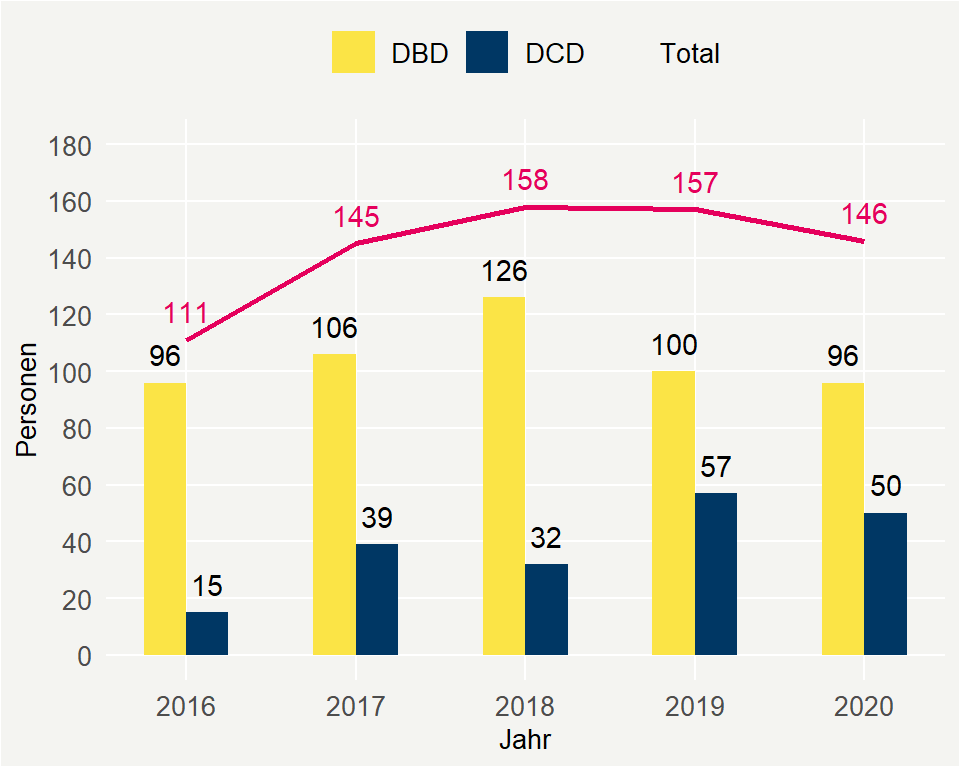

```r
number_height = -0.8
bar_with = 0.5

ggplot(data3.1, aes(x=Jahr, y=Anzahl, fill=Gruppe, group=Gruppe)) +

  # plot bars with numbers
  geom_bar(data = data3.1, stat="identity", position="dodge", width=bar_with) +
  geom_text(data = data3.1, aes(label=Anzahl), vjust=number_height,
            position = position_dodge(width=bar_with)) +

  # plot line with numbers
  geom_line(data = data3.1.totals, col = col$strongred.akzent, linewidth=1) +
  geom_text(data = data3.1.totals, aes(label=Anzahl), vjust=number_height,
            position = position_dodge(width=bar_with), col=col$strongred.akzent) +

  # some adjustments (colors, axes, etc)
  scale_fill_manual(values=c(col$yellow.donation,
                             col$blue.swt,
                             col$strongred.akzent)) +
  scale_y_continuous(breaks = seq(0,180,20), limits = c(0,180)) +
  ylab("Personen") +
  swt_style(grey_theme = TRUE)
```

## Tiny little helpers

Several helper functions are implemented to support statistical computing.

### Descriptive statistics and formatting

- `count_perc()` for the count and percent
- `mean_sd()` for the mean and standard deviation
- `median_irq()` for the median and interquartile range
- `miss_perc()` for the count and percent for missing data (`NA`)
- `tidy_pvalues()` for formatting p-values

```r
set.seed(1980)
data = data.frame(age = rnorm(n = 200, mean = 50, sd = 10))
data$hypertension = rbinom(n = 200, size = 1, prob = 0.20)

tab = data.frame(all = c(mean_sd(data$age),
                         count_perc(data$hypertension))
)

colnames(tab) = "Descriptives"
rownames(tab) = c("Age in years, mean (SD)", "Hypertension, count (%)")
tab
```

|  | Descriptives |
| --- | --- |
| Age in years, mean (SD) | 50.2 (10.7) |
| Hypertension, count (%) | 57 (28.5) |

### Missing data

The function `tidy_missing()` displays missing data of all the variables in a data frame.

```r
data$age[1:5] = NA
tidy_missing(data)
```

|  | Missing |
| --- | --- |
| age | 5 (2.5%) |
| hypertension | 0 (0.0%) |
| TOTAL | 5 (2.5) |

### Handling date and time

The `swt` package provides two functions for advanced handling of date and time.

- `num2date()`converts Excel days since origin to POSIXct data type (date/time).
- `date2num()` converts POSIXct data type (date/time) to Excel days since origin.

Using `num2date()` for all date variables will also handle the time zone consistently using `CET` time (and `CEST` during summer). Note that having mixed time zones, `UTC` and `CET`, can cause offsets of 1 hour.

If date and time data are provided in a consistent way, such as from SOAS, these functions are not necessary, and date and time can be handled in the usual way. However, date and time are sometimes entered inconsistently. If we force the data type to be a date using the option `col_types`, inconsistent values are discarded and show up as `NA`, which is not ideal. We also get a warning, see below.

```r
data = as.data.frame(read_xlsx(path = "../data/dates.xlsx", col_types = "date"))
```

```
Warning: Expecting date in A4 / R4C1: got '11.03.1980 11:11:11'
```

```r
data
```

| mydate |
| --- |
| 2021-08-22 16:43:01 |
| 2023-02-17 22:12:02 |
| NA |

An alternative is to import them as data type text. The dates show up as numbers and, if not recognized, as characters. The numbers are the number of days since 1899-12-30; this is an Excel convention.

```r
data = as.data.frame(read_xlsx(path = "../data/dates.xlsx", col_types = "text"))
data
```

| mydate |
| --- |
| 44430.696539351855 |
| 44974.925023148149 |
| 11.03.1980 11:11:11 |

We can use the function `num2date()` to convert numbers into dates. There is also a built-in filter that recognizes the alternative format, which can also be modified via the option; see `?num2date`.

```r
data$mydate = num2date(data$mydate, format = "%d.%m.%Y %H:%M:%OS", round = FALSE)
data
```

| mydate |
| --- |
| 2021-08-22 16:43:01 |
| 2023-02-17 22:12:02 |
| 1980-03-11 11:11:10 |

One disadvantage of handling dates as numbers is when performing data cleaning. For example, manually correcting dates or adding missing data may be necessary. This has to be done in numbers before the conversion into the `POSIXct` data type. However, the function `date2num()`can be used for this purpose.

```r
data = as.data.frame(read_xlsx(path = "../data/dates.xlsx", col_types = "text"))
data$mydate[3] = date2num("1980-03-11 02:10:00")
data$mydate = num2date(data$mydate)
data
```

| mydate |
| --- |
| 2021-08-22 16:43:01 |
| 2023-02-17 22:12:02 |
| 1980-03-11 02:10:00 |

## Clinical calculators

The `swt` package implemented a number of clinical calculators, for example, from published clinical prediction models.

- eGFR according to CKD-EPI 2021
- eGFR for pediatric patients according to Schwartz
- OPTN KDRI (2024 version)
- UK KDRI (2019 version)
- UK DCD Risk Score

Quick examples are shown below.

### CKD-EPI eGFR 2021

```r
egfr = egfr_ckd_epi(SCr = c(40, 110),
                    age = c(40, 50),
                    sex = c("M", "F"),
                    units = "SI")
data.frame(eGFR = egfr)
```

| eGFR |
| --- |
| 136 |
| 53 |

```r
assert(egfr == c(136, 53))
```

### Revised Schwartz Equation 2009

```r
egfr = egfr_schwartz(SCr = c(100, 110),
                     height = c(100, 120),
                     units = "SI")
data.frame(eGFR = egfr)
```

| eGFR |
| --- |
| 37 |
| 40 |

```r
assert(egfr == c(37, 40))
```

### OPTN KDRI

```r
kdri = optn_kdri(D_age = c(45, 15, 70),
                 D_height = c(183, 183, 183),
                 D_weight = c(75, 90, 100),
                 D_hypertension = c(TRUE, FALSE, TRUE),
                 D_diabetes = c(TRUE, FALSE, TRUE),
                 D_CVA = c(TRUE, FALSE, TRUE),
                 D_SCr = c(1, 1.8, 1.8),
                 D_DCD = c(TRUE, FALSE, TRUE))

kdri = round(kdri, digits = 2)
data.frame(KDRI = kdri)
```

| KDRI |
| --- |
| 1.36 |
| 0.56 |
| 2.10 |

```r
assert(kdri == c(1.36, 0.56, 2.10))
```

### UK KDRI

```r
kdri = uk_kdri(D_age = 45,
               D_height = 180,
               D_hypertension = TRUE,
               D_female = TRUE,
               D_CMV = TRUE,
               D_eGFR = 100,
               D_days_hosp = 5)

kdri = round(kdri, digits = 2)
data.frame(KDRI = kdri)
```

| KDRI |
| --- |
| 0.94 |

```r
assert(kdri == 0.94)
```

### UK DCD Risk Score

```r
score = uk_dcd_score(D_age = c(61, 60),
                     D_BMI = c(26, 25),
                     fWIT = c(31, 20),
                     CIT = c(7, 6),
                     R_age = c(61, 60),
                     R_MELD = c(26, 25),
                     retpx = c(TRUE, FALSE))

data.frame(Score = score)
```

| Score |
| --- |
| 27 |
| 0 |

```r
assert(score == c(27, 0))
```

## Statistical models

The `tidy_rmsfit()` function converts regression model results from the package `rms` into a tidy, publication-ready table. This works for

- `ols()` linear regression model (ordinary least squares)
- `lmr()` logistic regression model
- `cph()` Cox proportional hazards model

```r
set.seed(2025)

d = data.frame(x1 = runif(200),
               x2 = runif(200),
               x3 = as.factor(rbinom(200, 2, 0.5))
)

dd = datadist(d)
options(datadist="dd")

d$y <- d$x1 + d$x2 + rnorm(200)

fit = rms::ols(y ~ x1 + x2 + x3, data = d)
```

Regression model results are typically displayed in an untidy format by `summary()` and `anova()`, as shown below:

```r
summary(fit)
```

```
             Effects              Response : y

 Factor   Low     High    Diff.   Effect    S.E.    Lower 0.95 Upper 0.95
 x1       0.23003 0.78329 0.55326  0.670250 0.13141  0.41108   0.92942
 x2       0.25219 0.77842 0.52623  0.681250 0.12475  0.43521   0.92728
 x3 - 0:1 2.00000 1.00000      NA -0.196800 0.17276 -0.53752   0.14392
 x3 - 2:1 2.00000 3.00000      NA  0.081503 0.17186 -0.25744   0.42045
```

```r
anova(fit)
```

```
                Analysis of Variance          Response: y

 Factor     d.f. Partial SS MS         F     P
 x1           1   25.740338 25.7403376 26.01 <.0001
 x2           1   29.506389 29.5063894 29.82 <.0001
 x3           2    2.097779  1.0488895  1.06 0.3484
 REGRESSION   4   57.355444 14.3388609 14.49 <.0001
 ERROR      195  192.949861  0.9894865
```

The function `tidy_rmsfit()` combines the effect estimates and the test statistics into one single publication-ready table:

```r
tidy_rmsfit(fit, x3 = 0)
```

|  | Interquartile difference | Effect estimate (95%-CI) | F-value | d.f. | p-value |
| --- | --- | --- | --- | --- | --- |
| x1 | 0.55 (from 0.23 to 0.78) | 0.67 (from 0.41 to 0.93) | 26 | 1 | < 0.001 *** |
| x2 | 0.53 (from 0.25 to 0.78) | 0.68 (from 0.44 to 0.93) | 29.8 | 1 | < 0.001 *** |
| x3 | – | – | 1.06 | 2 | 0.35 |
| x3 1 | – | 0.20 (from -0.14 to 0.54) | – | – | – |
| x3 2 | – | 0.28 (from -0.11 to 0.67) | – | – | – |
| TOTAL | – | – | 14.5 | 4 | < 0.001 *** |
| ERROR | – | – | – | 195 | – |